# Allies and Enemies

**This homework is due Sunday April 10, 2016 at 11:59PM EST. When complete, submit your code in an R Markdown file and the knitted HTML via GitHub.**

# Introduction

The United Nations (UN) is an intergovernmental organization founded in 1946 to promote international cooperation. It now represents 193 member states. The General Assembly is the largest body, with a seat for every member of the UN. It discusses topics of international importance such as maintaining peace and security, providing humanitarian aid, and protecting human rights.

We will be analyzing a dataset containing the full history of General Assembly votes by each country to determine what countries vote similarly and which do not. We will also explore how this changes through time.

# Problem 1

We’ll start by loading the United Nations voting data into R and performing some data wrangling. We use data from this paper:

> Voeten, Erik; Strezhnev, Anton; Bailey, Michael, 2009, “United Nations General Assembly Voting Data”, http://hdl.handle.net/1902.1/12379, Harvard Dataverse, V11

In this problem, we will combine information from three sources to create the datasets that we will use to study voting behavior.

### Problem 1A

We have learned how to import text files into R. Here we are going to load a data object that is saved to a file. To get an idea of how this works try the following:

```r
temp_filename <- tempfile() ## creaate tempory file name
temp_object <- 1:5 ## create an R object
save(temp_object, file=temp_filename) ## save the r object to file
rm(temp_object) ## remove object
load(temp_filename) ## load object from file
temp_object ## note that it's back
```

```
## [1] 1 2 3 4 5
```

We usually use the suffix `.RData` or `.rda` for these objects.

The data for this project is stored as an `.RData` file. Go to [this web page](https://dataverse.harvard.edu/dataset.xhtml?persistentId=hdl:1902.1/12379). To get the `.RData` file, click on the Download button for `rawvotingdata13.tab` and choose the `RData format`.

To load the data set into R, use the `load()` function. Define the name of the object as `x` (but do NOT print it out as it has over 1 million rows).

```r
setwd("C:/Users/xiz933/Desktop/Files/Data Science/2016/xz2315-2016HW5")
load("rawvotingdata13.RData")
```

### Problem 1B

The first problem to overcome is that if you try to print this object, it will crash your R session – it’s just that big! (1051752 rows). So first wrap it in `tbl_df(x)`, and call it `votes`. After doing this you can erase `x` with `rm(x)`.

```r
library(dplyr)
votes <- tbl_df(x)
rm(x)
```

### Problem 1C

We note that the data is already arranged according to the rules of tidy data. There is one row for each observation and one column for each variable.

Download the `Codebook.pdf` file from [this page](https://dataverse.harvard.edu/dataset.xhtml?persistentId=hdl:1902.1/12379). How would you interpret the vote column? How many of each kind of vote are in this dataset?

```r
# vote - Vote choice
# 1 - Yes 2 - Abstain 3 - No 8 - Absent 9 - Not a member
table(votes$vote)
```

```
##
##      1      2      3      8      9
## 577756  93387  53891  72197 254521
```

Of the five types of votes, which three would provide information about the country’s position on an issue? Which two would not?

**Your answer here**:

> 1 - Yes or approval for an issue, 2 - Abstain, 3 - No or disapproval for an issue, would provide information about the country’s position on an issue; while 8- Absent and 9- Not a member would not.

Filter out the types of votes that do not provide information about our countries position on an issue from our dataset.

```r
votes <- filter(votes, vote %in% c(1,2,3))
```

### Problem 1D

According to the codebook, which column represents countries? What type of unique code is used to represent each country?

**Your answer here**:

> The column ccode represents countries, it uses a numeric code, called COW(Correlates of War) Country Codes, to represent each country.

Create new `country` column that contains country names based on this column. Hint: check out the [countrycode](https://cran.r-project.org/web/packages/countrycode/countrycode.pdf) package.

```r
library(countrycode)
votes$country <-countrycode(votes$ccode, origin="cown", destination = "country.name")
```

### Problem 1E

Before continuing let’s wrangle the country names a bit. We are renaming countries with long names and renaming Congo to distinguish it from Democratic Republic of Congo. We make use of the powerful remapping function `revalue()` from `plyr` package. You should **not** load `plyr` though as it will create confusion with `dplyr` functions.

```r
library(tidyr)
mapping <- c("United States"="USA",
          "United Kingdom"="UK",
          "Korea, Republic of"="South Korea",
          "Lao People's Democratic Republic"="Laos",
          "Yemen People's Republic"="South Yemen",
          "Saint Vincent and the Grenadines"="Saint Vincent",
          "Congo"="Congo Republic")
votes <- votes %>%
         mutate(country = plyr::revalue(country, mapping)) %>%
         separate(country, into = c("country", "extra"), sep=",", fill="right")
```

Right now we have information about how every country voted on every resolution. But we do not have any information about the resolutions themselves (e.g. not what their title or topic was, or what date they were voted on). Next, we will bring this data in as well.

This data is provided as `descriptions.csv`. Read it in using the `readr` package and wrangle it as shown below:

```r
library(readr)

url <- "https://raw.githubusercontent.com/datasciencelabs/data/master/un-resolutions-descriptions.csv"
descriptions <- read_csv(url, col_types = list(date = col_date("%m/%d/%y")))

## from warning and looking at csv we see
## line 1483 has an extra "
## it's supposed to be a 0
descriptions[1483,"ec"] <-0

library(lubridate)
y <- year(descriptions$date)
year(descriptions$date) <- ifelse(y > 2030, y - 100, y)
```

Count the number of votes that were taken in each year. Create a line graph of the number of votes per year.

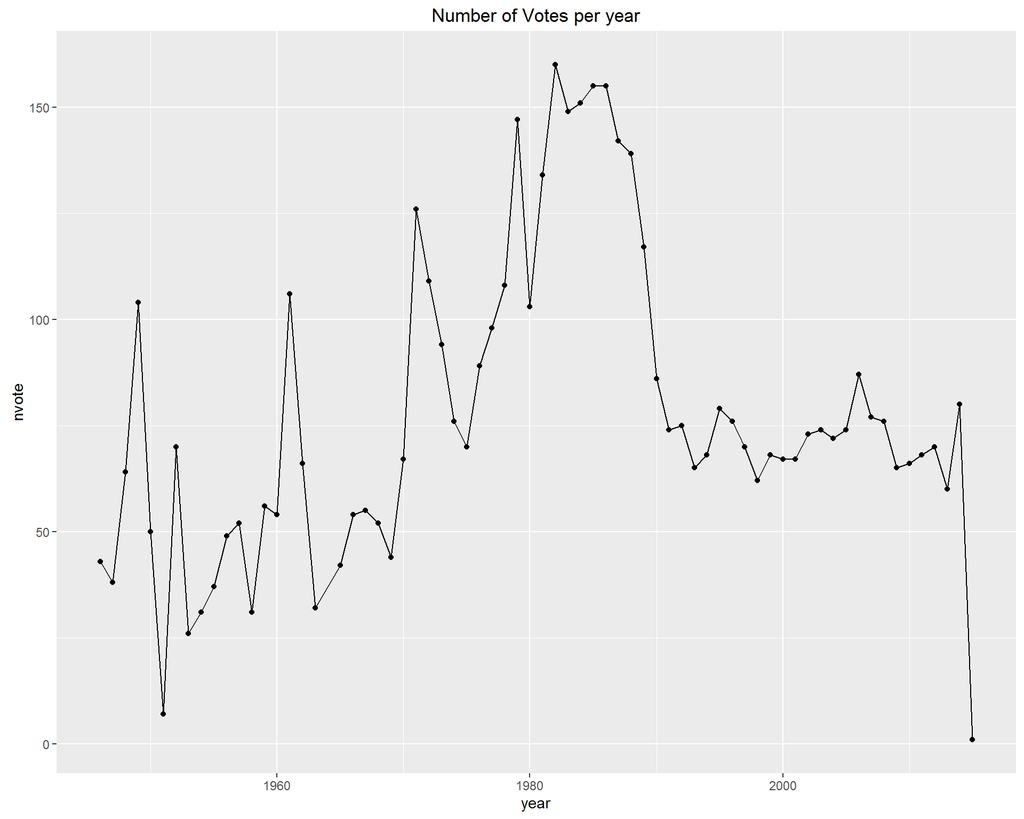

```r
library(ggplot2)
descriptions %>%
  mutate(year=year(date)) %>%
  group_by(year) %>%
  summarise(nvote=n()) %>%
  ungroup %>%
  ggplot(aes(x=year, y=nvote)) +
  geom_point() +
  geom_line() +
  ggtitle("Number of Votes per year")
```

What year would we want to filter out from the dataset because there was only one vote?

```r
descriptions %>%
            mutate(year=year(date)) %>%
            group_by(year) %>%
            summarise(nvote=n()) %>%
            ungroup %>%
            filter(nvote<=1)
```

```
## Source: local data frame [1 x 2]
##
##    year nvote
##   (dbl) (int)
## 1  2015     1
```

**Your answer here**:

> 2015 has only one vote !

Filter it out now.

```r
descriptions <- descriptions %>%
                filter(year(date) != 2015)
```

### Problem 1F

Read the `Codebook.pdf` about this dataset. Who classified certain votes as “important”?

**Your answer here**:  
> Votes deemed “important” by the U.S. state Department.

What percent of votes in history were categorized as “important”? > 6.877% of votes were considered as “important”.

```r
prop.table(table(descriptions$importantvote))
```

```
##
##          0          1
## 0.93122781 0.06877219
```

The most interesting analyses can be done by combining the description and country-voting data.

Join the `description` and country-voting data (`votes`) to create a new data set. Remove the `yes`, `no`, and `abstain` columns from the `description` dataset. These are per-vote summaries that we do not need any more (and could be misleading). The final dataset should be called `votes`, which you will continue to use throughout the homework.

```r
votes <- left_join(votes, select(descriptions, -yes,-no,-abstain), by=c("session", "rcid"))
```

# Problem 2

### Problem 2A

Canada and the US have been allies since the UN was created. We can create a matrix of all votes for these two countries using the `spread()` function in `tidyr` package like this:

```r
library(tidyr)
y <- votes %>%
  filter(country %in% c("USA", "Canada")) %>%
  mutate(year = year(date)) %>%
  select(rcid, year, importantvote, country, vote) %>%
  spread(country, vote)
```

We can see how often they have voted together in important votes and not-important votes:

```r
y %>%
    group_by(importantvote) %>%
    summarize(mean(USA==Canada, na.rm=TRUE))
```

```
## Source: local data frame [3 x 2]
##
##   importantvote mean(USA == Canada, na.rm = TRUE)
##           (int)                             (dbl)
## 1             0                         0.5501014
## 2             1                         0.6475410
## 3            NA                         1.0000000
```

Compute the percentage in which the US and Canada voted the same. Calculate this percentage for each year and call it `agreement`. Fit a linear model using `lm()` to predict `agreement` with `year`.

```r
agreement <- votes %>%
             filter(country %in% c("USA", "Canada")) %>%
             mutate(year = year(date)) %>%
             select(rcid, year, importantvote, country, vote) %>%
             spread(country, vote) %>%
             group_by(year) %>%
             summarise(agreement=mean(USA==Canada,na.rm=TRUE))

fit <-lm(agreement~year, data=agreement)
summary(fit)
```

```
##
## Call:
## lm(formula = agreement ~ year, data = agreement)
##
## Residuals:
##      Min       1Q   Median       3Q      Max
## -0.26657 -0.08793 -0.03213  0.08515  0.44665
##
## Coefficients:
##               Estimate Std. Error t value Pr(>|t|)
## (Intercept) 14.3779138  1.6821971   8.547 2.78e-12 ***
## year        -0.0069635  0.0008495  -8.198 1.17e-11 ***
## ---
## Signif. codes:  0 '***' 0.001 '**' 0.01 '*' 0.05 '.' 0.1 ' ' 1
##
## Residual standard error: 0.1399 on 66 degrees of freedom
##   (1 observation deleted due to missingness)
## Multiple R-squared:  0.5045, Adjusted R-squared:  0.497
## F-statistic:  67.2 on 1 and 66 DF,  p-value: 1.172e-11
```

What is the trend predicted by the linear model? Is it statistically significant?

**Your answer here**:

> The effect estimate for year on agreement percentage is -0.0069635 (p-value<.005), so the trend predicted by the linear model is decreasing or negative, and also is statistically significant.

### Problem 2B

In the previous problem we found a negative trend in the agreement between the USA and Canada throughout the years. Interpreting this linear model would imply that disagreement between these two counties was worse during the Clinton administration (1992-2000) than the Reagan administration (1980-1989).

Now, instead of blindly interpreting the regression results, plot the data and use a smoother to estimate a trend. Based on this analysis, how do thes Regan and Clinton administrations compare?

**Hint**: Make sure to pick a window size or span that creates a trend that goes through data.

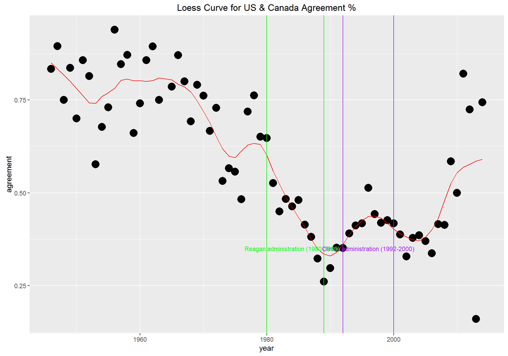

```r
# Local weighted regression (loess) smoothing
library(broom)
fit<-augment(loess(agreement~year, degree=1, span = 0.15, data=agreement))
fit %>%
    ggplot(aes(year, agreement)) +
    geom_point(cex=5) +
    geom_line(aes(x=year, y=.fitted), data=fit, color="red")+
    geom_vline(xintercept = c(1992,2000), col="purple")+
    geom_vline(xintercept = c(1980,1989), col="green")+
    annotate("text", x = 1996, y = 0.35, label = "Clinton administration (1992-2000)",col='purple',size=3)+
    annotate("text", x = 1984, y = 0.35, label = "Reagan administration (1980-1989)",col='green',size=3) +
    ggtitle("Loess Curve for US & Canada Agreement %")
```

> During Regan administration, there is a clear negative trend in the agreement between the USA and Canada throughout the years; however, during Clinton administration, local weighted regression sugggests a curvilinear-first increasing then decreasing trend.

### Problem 2C

Make the plot above for the agreement through time between the US and the following countries: Israel, UK, Mexico, Cuba, and China. Make two plots: one for important votes to non-important votes.

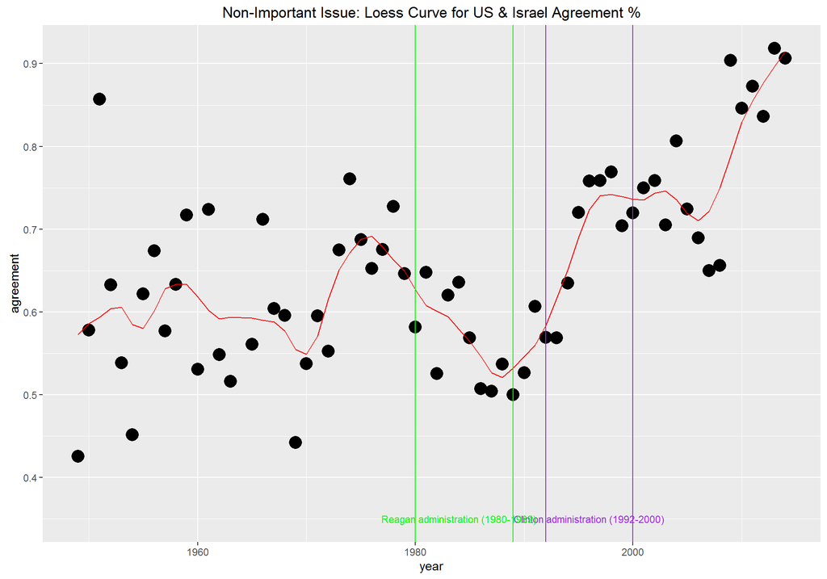

```r
#Israel
agree.notimport <- votes %>%
             filter(country %in% c("USA", "Israel"), importantvote==0) %>%
             mutate(year = year(date)) %>%
             select(rcid, year, importantvote, country, vote) %>%
             spread(country, vote) %>%
             group_by(year ) %>%
             summarise(agreement=mean(USA==Israel,na.rm=TRUE))


agree.import <- votes %>%
             filter(country %in% c("USA", "Israel"), importantvote==1) %>%
             mutate(year = year(date)) %>%
             select(rcid, year, importantvote, country, vote) %>%
             spread(country, vote) %>%
             group_by(year ) %>%
             summarise(agreement=mean(USA==Israel,na.rm=TRUE))


fit.notimport<-augment(loess(agreement~year, degree=1, span = 0.15, data=agree.notimport))
fit.import<-augment(loess(agreement~year, degree=1, span = 0.15, data=agree.import))

fit.notimport %>%
    ggplot(aes(year, agreement)) +
    geom_point(cex=5) +
    geom_line(aes(x=year, y=.fitted), data=fit.notimport, color="red")+
    geom_vline(xintercept = c(1992,2000), col="purple")+
    geom_vline(xintercept = c(1980,1989), col="green")+
    annotate("text", x = 1996, y = 0.35, label = "Clinton administration (1992-2000)",col='purple',size=3)+
    annotate("text", x = 1984, y = 0.35, label = "Reagan administration (1980-1989)",col='green',size=3) +
    ggtitle("Non-Important Issue: Loess Curve for US & Israel Agreement %")
```

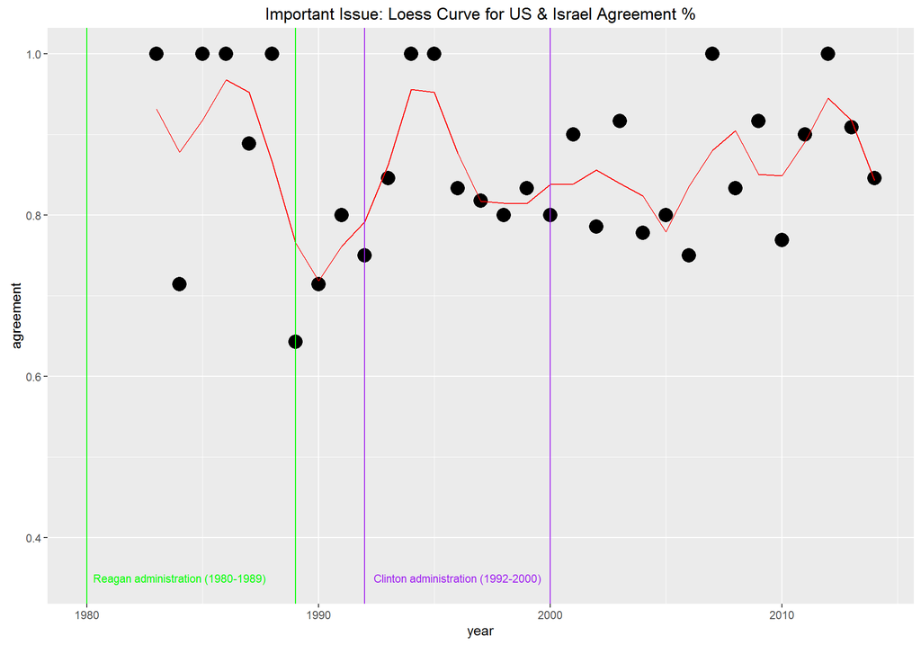

```r
fit.import %>%
    ggplot(aes(year, agreement)) +
    geom_point(cex=5) +
    geom_line(aes(x=year, y=.fitted), data=fit.import, color="red")+
    geom_vline(xintercept = c(1992,2000), col="purple")+
    geom_vline(xintercept = c(1980,1989), col="green")+
    annotate("text", x = 1996, y = 0.35, label = "Clinton administration (1992-2000)",col='purple',size=3)+
    annotate("text", x = 1984, y = 0.35, label = "Reagan administration (1980-1989)",col='green',size=3) +
    ggtitle("Important Issue: Loess Curve for US & Israel Agreement %")
```

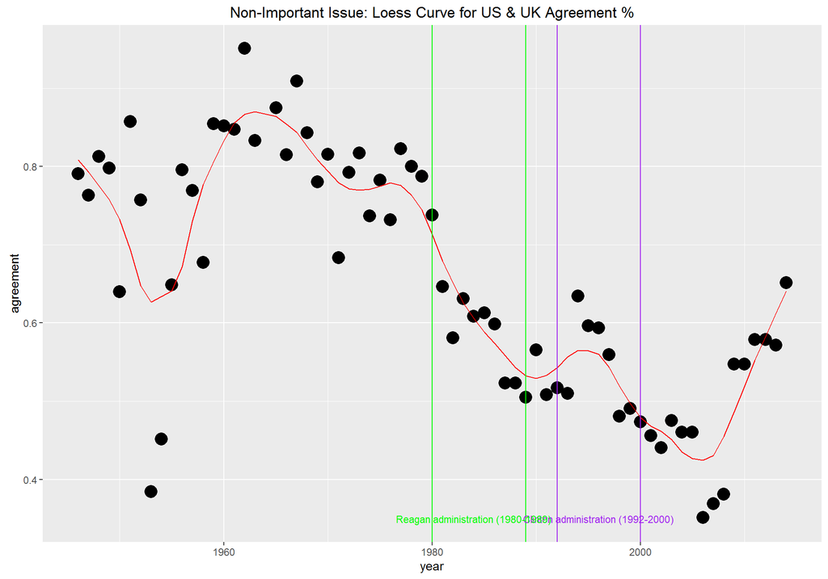

```r
# UK
agree.notimport <- votes %>%
             filter(country %in% c("USA", "UK"), importantvote==0) %>%
             mutate(year = year(date)) %>%
             select(rcid, year, importantvote, country, vote) %>%
             spread(country, vote) %>%
             group_by(year ) %>%
             summarise(agreement=mean(USA==UK,na.rm=TRUE))


agree.import <- votes %>%
             filter(country %in% c("USA", "UK"), importantvote==1) %>%
             mutate(year = year(date)) %>%
             select(rcid, year, importantvote, country, vote) %>%
             spread(country, vote) %>%
             group_by(year) %>%
             summarise(agreement=mean(USA==UK,na.rm=TRUE))


fit.notimport<-augment(loess(agreement~year, degree=1, span = 0.15, data=agree.notimport))
fit.import<-augment(loess(agreement~year, degree=1, span = 0.15, data=agree.import))

fit.notimport %>%
    ggplot(aes(year, agreement)) +
    geom_point(cex=5) +
    geom_line(aes(x=year, y=.fitted), data=fit.notimport, color="red")+
    geom_vline(xintercept = c(1992,2000), col="purple")+
    geom_vline(xintercept = c(1980,1989), col="green")+
    annotate("text", x = 1996, y = 0.35, label = "Clinton administration (1992-2000)",col='purple',size=3)+
    annotate("text", x = 1984, y = 0.35, label = "Reagan administration (1980-1989)",col='green',size=3) +
    ggtitle("Non-Important Issue: Loess Curve for US & UK Agreement %")
```

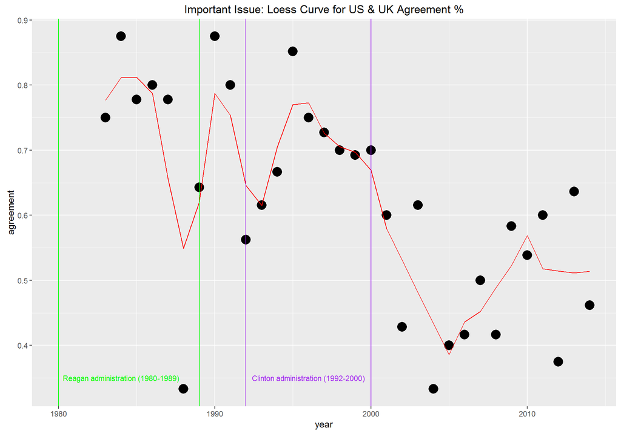

```r
fit.import %>%
    ggplot(aes(year, agreement)) +
    geom_point(cex=5) +
    geom_line(aes(x=year, y=.fitted), data=fit.import, color="red")+
    geom_vline(xintercept = c(1992,2000), col="purple")+
    geom_vline(xintercept = c(1980,1989), col="green")+
    annotate("text", x = 1996, y = 0.35, label = "Clinton administration (1992-2000)",col='purple',size=3)+
    annotate("text", x = 1984, y = 0.35, label = "Reagan administration (1980-1989)",col='green',size=3) +
    ggtitle("Important Issue: Loess Curve for US & UK Agreement %")
```

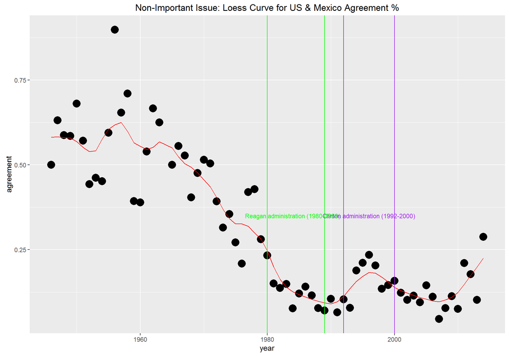

```r
#Mexico
agree.notimport <- votes %>%
             filter(country %in% c("USA", "Mexico"), importantvote==0) %>%
             mutate(year = year(date)) %>%
             select(rcid, year, importantvote, country, vote) %>%
             spread(country, vote) %>%
             group_by(year ) %>%
             summarise(agreement=mean(USA==Mexico,na.rm=TRUE))


agree.import <- votes %>%
             filter(country %in% c("USA", "Mexico"), importantvote==1) %>%
             mutate(year = year(date)) %>%
             select(rcid, year, importantvote, country, vote) %>%
             spread(country, vote) %>%
             group_by(year ) %>%
             summarise(agreement=mean(USA==Mexico,na.rm=TRUE))


fit.notimport<-augment(loess(agreement~year, degree=1, span = 0.15, data=agree.notimport))
fit.import<-augment(loess(agreement~year, degree=1, span = 0.15, data=agree.import))

fit.notimport %>%
    ggplot(aes(year, agreement)) +
    geom_point(cex=5) +
    geom_line(aes(x=year, y=.fitted), data=fit.notimport, color="red")+
    geom_vline(xintercept = c(1992,2000), col="purple")+
    geom_vline(xintercept = c(1980,1989), col="green")+
    annotate("text", x = 1996, y = 0.35, label = "Clinton administration (1992-2000)",col='purple',size=3)+
    annotate("text", x = 1984, y = 0.35, label = "Reagan administration (1980-1989)",col='green',size=3) +
    ggtitle("Non-Important Issue: Loess Curve for US & Mexico Agreement %")
```

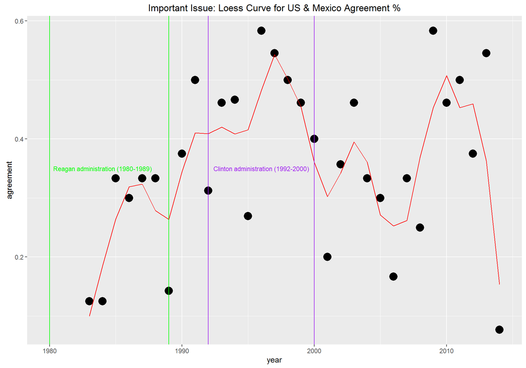

```r
fit.import %>%
    ggplot(aes(year, agreement)) +
    geom_point(cex=5) +
    geom_line(aes(x=year, y=.fitted), data=fit.import, color="red")+
    geom_vline(xintercept = c(1992,2000), col="purple")+
    geom_vline(xintercept = c(1980,1989), col="green")+
    annotate("text", x = 1996, y = 0.35, label = "Clinton administration (1992-2000)",col='purple',size=3)+
    annotate("text", x = 1984, y = 0.35, label = "Reagan administration (1980-1989)",col='green',size=3) +
    ggtitle("Important Issue: Loess Curve for US & Mexico Agreement %")
```

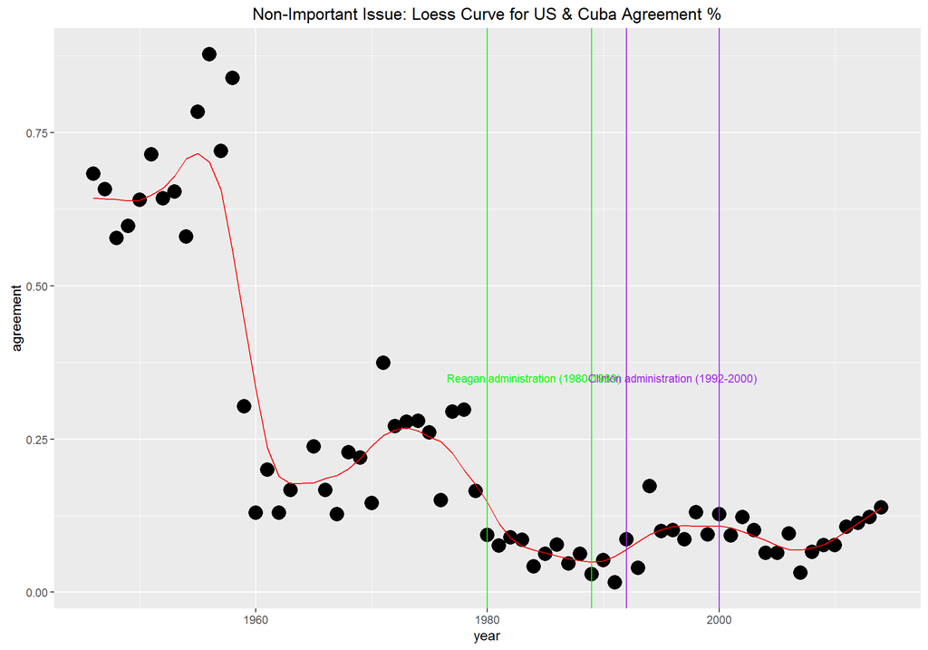

```r
# Cuba
agree.notimport <- votes %>%
             filter(country %in% c("USA", "Cuba"), importantvote==0) %>%
             mutate(year = year(date)) %>%
             select(rcid, year, importantvote, country, vote) %>%
             spread(country, vote) %>%
             group_by(year ) %>%
             summarise(agreement=mean(USA==Cuba,na.rm=TRUE))


agree.import <- votes %>%
             filter(country %in% c("USA", "Cuba"), importantvote==1) %>%
             mutate(year = year(date)) %>%
             select(rcid, year, importantvote, country, vote) %>%
             spread(country, vote) %>%
             group_by(year ) %>%
             summarise(agreement=mean(USA==Cuba,na.rm=TRUE))


fit.notimport<-augment(loess(agreement~year, degree=1, span = 0.15, data=agree.notimport))
fit.import<-augment(loess(agreement~year, degree=1, span = 0.15, data=agree.import))

fit.notimport %>%
    ggplot(aes(year, agreement)) +
    geom_point(cex=5) +
    geom_line(aes(x=year, y=.fitted), data=fit.notimport, color="red")+
    geom_vline(xintercept = c(1992,2000), col="purple")+
    geom_vline(xintercept = c(1980,1989), col="green")+
    annotate("text", x = 1996, y = 0.35, label = "Clinton administration (1992-2000)",col='purple',size=3)+
    annotate("text", x = 1984, y = 0.35, label = "Reagan administration (1980-1989)",col='green',size=3) +
    ggtitle("Non-Important Issue: Loess Curve for US & Cuba Agreement %")
```

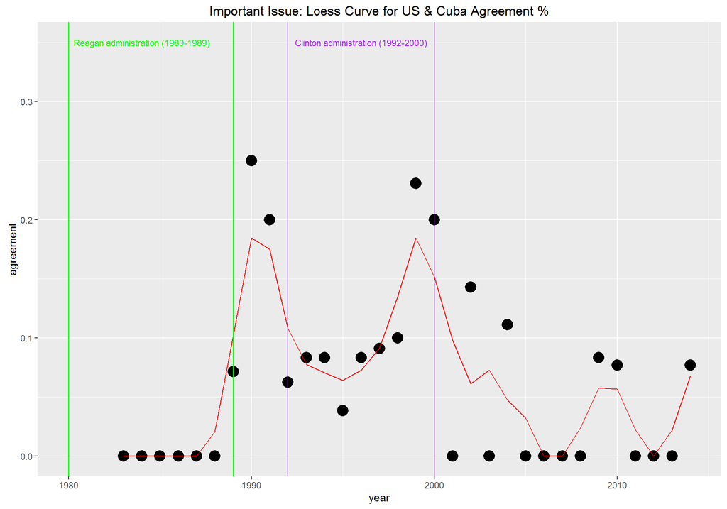

```r
fit.import %>%
    ggplot(aes(year, agreement)) +
    geom_point(cex=5) +
    geom_line(aes(x=year, y=.fitted), data=fit.import, color="red")+
    geom_vline(xintercept = c(1992,2000), col="purple")+
    geom_vline(xintercept = c(1980,1989), col="green")+
    annotate("text", x = 1996, y = 0.35, label = "Clinton administration (1992-2000)",col='purple',size=3)+
    annotate("text", x = 1984, y = 0.35, label = "Reagan administration (1980-1989)",col='green',size=3) +
    ggtitle("Important Issue: Loess Curve for US & Cuba Agreement %")
```

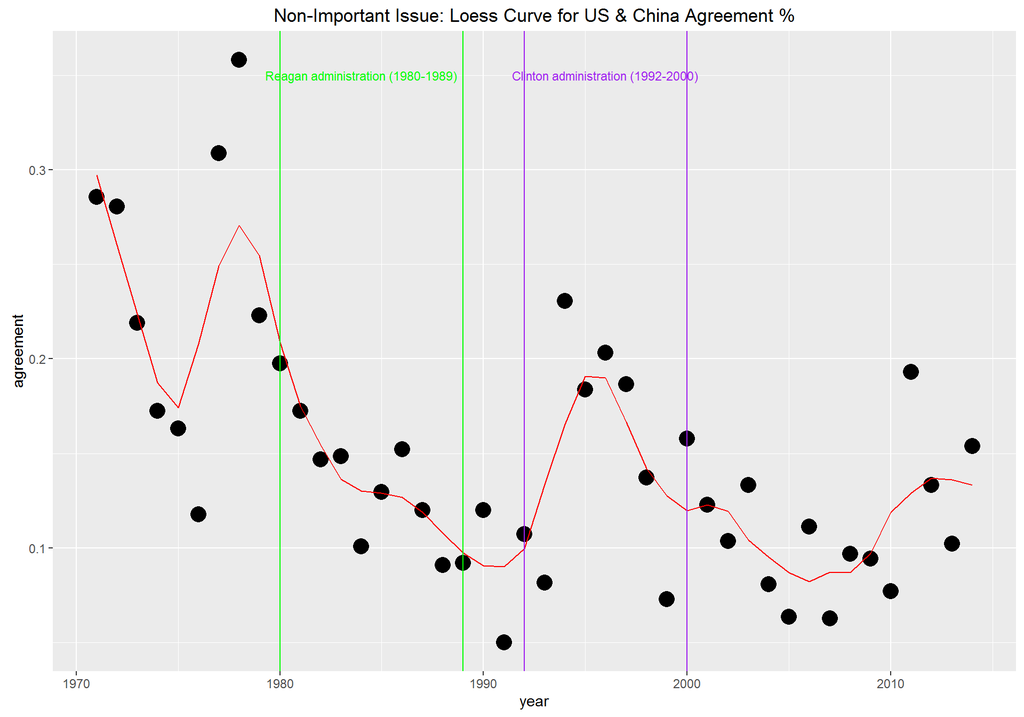

```r
#China
agree.notimport <- votes %>%
             filter(country %in% c("USA", "China"), importantvote==0) %>%
             mutate(year = year(date)) %>%
             select(rcid, year, importantvote, country, vote) %>%
             spread(country, vote) %>%
             group_by(year ) %>%
             summarise(agreement=mean(USA==China,na.rm=TRUE))


agree.import <- votes %>%
             filter(country %in% c("USA", "China"), importantvote==1) %>%
             mutate(year = year(date)) %>%
             select(rcid, year, importantvote, country, vote) %>%
             spread(country, vote) %>%
             group_by(year ) %>%
             summarise(agreement=mean(USA==China,na.rm=TRUE))


fit.notimport<-augment(loess(agreement~year, degree=1, span = 0.15, data=agree.notimport))
fit.import<-augment(loess(agreement~year, degree=1, span = 0.15, data=agree.import))

fit.notimport %>%
    ggplot(aes(year, agreement)) +
    geom_point(cex=5) +
    geom_line(aes(x=year, y=.fitted), data=fit.notimport, color="red")+
    geom_vline(xintercept = c(1992,2000), col="purple")+
    geom_vline(xintercept = c(1980,1989), col="green")+
    annotate("text", x = 1996, y = 0.35, label = "Clinton administration (1992-2000)",col='purple',size=3)+
    annotate("text", x = 1984, y = 0.35, label = "Reagan administration (1980-1989)",col='green',size=3) +
    ggtitle("Non-Important Issue: Loess Curve for US & China Agreement %")
```

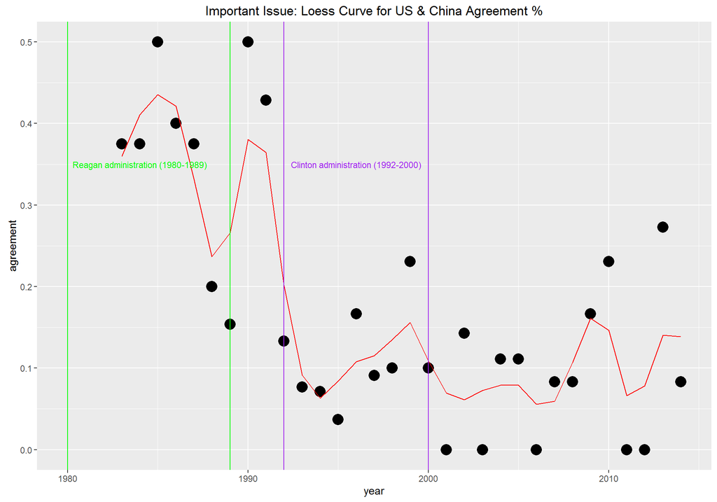

```r
fit.import %>%
    ggplot(aes(year, agreement)) +
    geom_point(cex=5) +
    geom_line(aes(x=year, y=.fitted), data=fit.import, color="red")+
    geom_vline(xintercept = c(1992,2000), col="purple")+
    geom_vline(xintercept = c(1980,1989), col="green")+
    annotate("text", x = 1996, y = 0.35, label = "Clinton administration (1992-2000)",col='purple',size=3)+
    annotate("text", x = 1984, y = 0.35, label = "Reagan administration (1980-1989)",col='green',size=3) +
    ggtitle("Important Issue: Loess Curve for US & China Agreement %")
```

Describe the observed patterns.

**Your answer here**:

> During Regan administration: * US and Israel had negative trend on the agreement of non-important issues; but almost flat trend on important ones. * US and UK had negative trends on agreement of both non-important and important issues. * US and Mexico had a negative trend on the agreement of non-important issues; but positive trend on important ones. * US and Cuba had a negative trend on the agreement of non-important issues; but positive trend on important ones. * US and China had negative trends on agreement of both non-important and important issues.

> During Clinton administration: * US and Israel had positive trend on the agreement of non-important issues;but a curvilinear(first positive then negative) trend on important issues. * US and UK had negative trends on agreement of both non-important; but curvilinear (first positive and then turning to negative) trend on important issues. * US and Mexico had a curvilinear (first positive and then turn to negative) trends on both non-important and important issues. * US and Cuba had flat trends on the agreement of non-important issues; but a positive trend on the agreement of important issues. * US and China had a positive-then-negative trend on the agreement of non-important issues; but a almost flat trend on important ones.

# Problem 3

In this problem, we will focus only on important votes. To get a better idea of who votes together we can compute a distance between each country. We will focus on countries that voted more than 95% of time in the 368 votes

```r
countries <- votes %>%
                filter(importantvote==1) %>%
                group_by(country) %>%
                summarize(p=n()/368) %>%
                filter(p>=0.95) %>%
                .$country
```

We can create a matrix with all the votes using the `spread()` function:

```r
tmp <- votes %>%
    filter(country %in% countries & year(date) >= 1980 & importantvote == 1) %>%
    select(rcid, country, vote) %>%
    spread(country, vote)

X <- as.matrix(tmp[,-1])
rownames(X) <- tmp$rcid
```

### Problem 3A

Create a distance matrix between each country. Call this matrix `d`.

**Hint**: Use the `dist()` function, but note that `X` has countries in the columns and `dist()` computes distances between rows. Look at the `dist` help file for more infomration. You can use the default `method = "Euclidean"` in the `dist()` function. You can switch rows to columns using the `t()` (transpose) function. Finally, once you create the distance matrix `d` you can visualize it using `heatmap()` or `hclust()`.

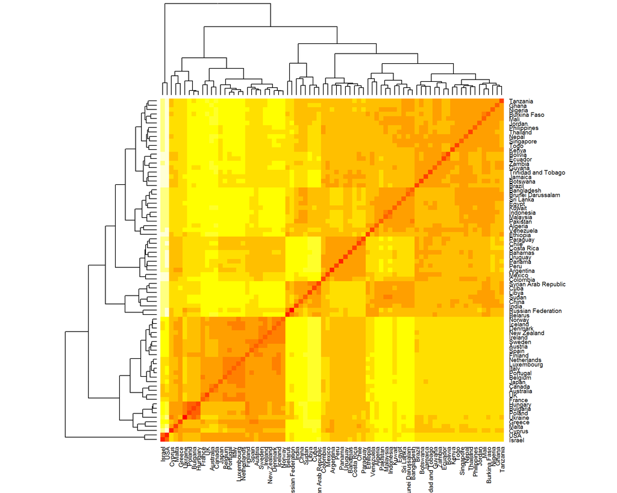

```r
d<-dist(t(X),method="euclidean")
heatmap(as.matrix(d))
```

What country is closest to US? Which is furthest?

```r
US.d <-c(as.matrix(d)["USA",])
US.d[which.min(US.d[US.d>0])]
```

```
##   Israel
## 9.402246
```

```r
US.d[which.max(US.d)]
```

```
##     Cuba
## 34.15195
```

**Your answer here**:

> Israel is closest to US, CUba is the durthest from US.

### Problem 3B

Given how close some countries are and how far others are to US in voting, we should be able to predict how the US will vote based on others. Let’s try to implement a machine learning algorithm to do this.

Use the `votes` data set to create a new dataset with seven columns. One column will represent the USA vote as the outcome (call it `y`) and the last six columns will be the vote from the six countries examined above in Problem 2 (include Canada), which will be used a predictors in our machine learning algorithm. Only consider the important votes. In the column for the USA vote column (`y`), remove the `Abstain` votes and only consider the `Yes` and `No` votes from the USA. Tranform the USA vote column (`y`) to contain only 0s and 1s where 0 = `No` vote and 1 = `Yes` vote.

```r
mydata <- votes %>%
      filter(country %in% c("USA", "Israel", "UK", "Mexico", "Cuba", "China", "Canada"), importantvote==1) %>%
      filter(vote %in% c(1,3)) %>% #remove "Abstain"
      mutate(vote2=ifelse(vote==1,1,0)) %>% #recode voting results
      select(rcid, country, vote2) %>%
      spread(country, vote2) %>%
      rename(y=USA)
```

Use the `caret` R package to split the data into a training set with 80% of data and a test set with the remaing 20%. Then use `glm()` to build a model. What is the accuracy?

```r
library(caret)
set.seed(02138)
TrainIndex  <- createDataPartition(y=mydata$rcid, p=0.8, times=1)
train_set <-slice(mydata, TrainIndex$Resample1)
test_set <-slice(mydata, - TrainIndex$Resample1)

glm_fit <- glm(y~Canada+China+Cuba+Israel+Mexico+UK,data =train_set,family="binomial")

y_hat <- predict(glm_fit, newdata = test_set, type = "response") #default binomial model the default predictions are of log-odds (probabilities on logit scale) and type = "response" gives the predicted probabilities

library(e1071)
tab <- table(pred=round(y_hat), truth=test_set$y)
confusionMatrix(tab)$tab
```

```
##     truth
## pred  0  1
##    0 16  1
##    1  2 12
```

```r
confusionMatrix(tab)$overall["Accuracy"]
```

```
##  Accuracy
## 0.9032258
```

> The Accuracy is 0.9032258.

### Problem 3C

We see that obtain a very high accuracy, but note that this is a random variable due to the random split of our data. Try 10 new random splits and report on how much our accuracy changes.

```r
Accuracy <-rep(NA,10)
for (i in 1:10){
  TrainIndex  <- createDataPartition(y=mydata$rcid, p=0.8, times=1)
  train_set <-slice(mydata, TrainIndex$Resample1)
  test_set <-slice(mydata, - TrainIndex$Resample1)
  glm_fit <- glm(y~Canada+China+Cuba+Israel+Mexico+UK,data =train_set,family="binomial")
  y_hat <- predict(glm_fit, newdata = test_set, type = "response")
  tab <- table(pred=round(y_hat), truth=test_set$y)
  Accuracy[i]<-confusionMatrix(tab)$overall["Accuracy"]
}
#Try 10 new random splits and report on how much our accuracy changes.
Accuracy
```

```
##  [1] 0.9411765 0.9600000 0.9200000 0.9629630 0.9600000 0.9600000 0.9583333
##  [8] 0.9615385 0.9310345 0.8888889
```

> Accuracy varies from 88.9% to 96.3%.

### Problem 3D

Compare your `glm()` model to a `knn()`. Use the `train()` function to run 10 cross validations with leaving out 80% of the data. Plot your results.

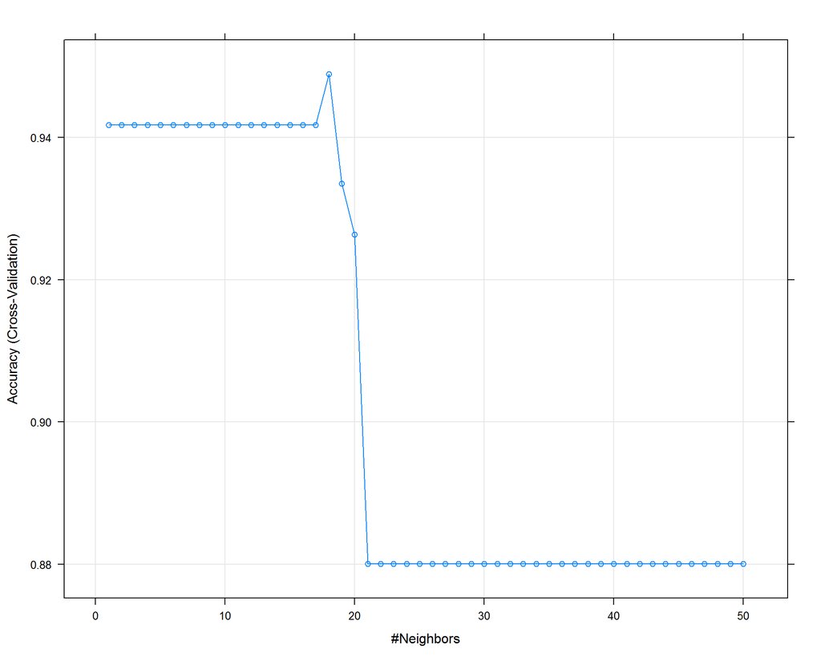

```r
set.seed(02138)

mydata<-mutate(mydata, y=as.factor(y))

control <- trainControl(method='cv',number=10,p=0.8)

Accuracy<-train(data=mydata,
                y~Canada+China+Cuba+Israel+Mexico+UK,
                method='knn',
                trControl=control,
                tuneGrid=data.frame(k=seq(1,50,1)),
                metric="Accuracy")

plot(Accuracy)
```

How many nearest neighbors should we use?

**Your answer here**: > We should use k=18 nearest neighbors.